# Exploring sensitivity of Time-varing model

testing RLS algorithm

Packages and such

```r
library(ggplot2)
library(devtools)
library(tibble)
library(magrittr) #for %<>%
set.seed(100) #for consistency in noise function
load_all()
```

```
ℹ Loading impulseResponse
```

The goal is trying to figure out how well the time-varying model predicts/recovers the parameters of an athlete.

```r
params_list_1 = list(c(250,.1,.1,25,15), c(250,.5,.5,25,1))
training_load_1 <- c(rep(100,100))
change_date <- 50

test_1 <- list(params_list_1,
               training_load_1,
               change_date)
```

A function that turns our test into the “actual” performance, given by the time-invariant impulse-response

```r
perf_varying_params <- function(test){
  params_list = test[[1]]
  training_load = test[[2]]
  change_date = test[[3]]
  c(
    predictedPerformance(params_list[[1]], training_load[1:change_date]),
    na.omit(predictedPerformance(params_list[[2]], training_load)[change_date+1:length(training_load)])
  )
}
non_noisy_perf_1 <- perf_varying_params(test_1)
```

An intermediate function that turns our test into a tibble that contains the actual parameter values used on the days of the test. This is used to graph our predicted paramter values against.

```r
actual_params_to_tib <- function(test){
  params_list = test[[1]]
  training_load = test[[2]]
  length_first_params = test[[3]]
  length_second_params = length(training_load)
  params_1 = params_list[[1]]
  params_2 = params_list[[2]]
  first_length = length_first_params
  second_length = length_second_params - length_first_params
  tibble(
    "day" = 1:length(training_load),
    "p_0" = c(rep(params_1[[1]], first_length),
              rep(params_2[[1]], second_length)
    ),
    "k_1" = c(rep(params_1[[2]], first_length),
              rep(params_2[[2]], second_length)
    ),

    "k_2" = c(rep(params_1[[3]], first_length),
              rep(params_2[[3]], second_length)
    ),
    "tau_1" = c(rep(params_1[[4]], first_length),
                rep(params_2[[4]], second_length)
    ),
    "tau_2" = c(rep(params_1[[5]], first_length),
                rep(params_2[[5]], second_length)
    )
  )
}
```

Applying noise to this model (with helper function that makes noise)

```r
noise_fn <- function(x,  sd){
  x+rnorm(1, mean = 0, sd = sd)
}

noisy_perf_1 = purrr::map_dbl(non_noisy_perf_1, noise_fn, sd = 1)
```

```r
performance_tib = tibble::tibble(
  day = c(1:100),
  non_noisy = non_noisy_perf_1,
  noisy = noisy_perf_1
)

# plot <- ggplot(performance_tib, aes(x = day, y = non_noisy))+
#   geom_line(color = "red")+
#   geom_line(aes(y=noisy), color = "blue")
# plot
```

Running RLS algorithm with the noisy performance

```r
prediction_noisy <- RLS_predicted_performance(
      training_load_1,
      noisy_perf_1,
      250,
      alpha = .55,
      delta = 1000,
      c(1,50),
      1,
      c(1,50),
      1
    )
#prediction_noisy[[2]]

data_1 <- tibble(
  "day" = c(1:100),
  "pred_perf" = as.numeric(prediction_noisy[[1]]),
  "perf" = noisy_perf_1
)

plot_1 <- ggplot(data_1, aes(day, pred_perf))+
  geom_line()+
  geom_line(aes(x = day, y=perf), color ="red")
plot_1
```

[output not shown]

The model works well starting with `alpha=.55`

Thought it was easier to make a function `prediction_with_alpha(performance, alpha, ...)` that plots the RLS algorithm – with `alpha=alpha` and `predicted_performance = predicted parameter` – given in `...`against that acutal paramters.

```r
#turing output of RLS function to something usable
####could implement this in RLS function
lists_to_tibble <- function(list_of_lists){
  len=length(list_of_lists)
  list_0 <- c(rep(0,len))
  out=tibble(
    "day" = 1:len,
    "p_0" = list_0,
    "k_1" = list_0,
    "k_2" = list_0,
    "tau_1" = list_0,
    "tau_2" = list_0
  )
  for(i in 1:len){
    for(j in 2:6){
     out[i,j] = list_of_lists[[i]][[j-1]]
    }
  }
  out
}

#The actually cool function
prediction_with_alpha <- function(test,
                                  alpha,
                                  list_graph = list("k_1",
                                                   "k_2",
                                                   "tau_1",
                                                   "tau_2",
                                                   "performance",
                                                   "SSE"),
                                  noise = FALSE,
                                  sd = 1
                                  ){
  #to include noise in measuring performance.
  actual_performance <- perf_varying_params(test)
  if (noise==TRUE){
    actual_performance <- purrr::map_dbl(actual_performance, noise_fn, sd)
  }

  actual_params_tib <- actual_params_to_tib(test)
  actual_params_tib %<>% add_column("performance" = actual_performance,
                                    "SSE" = c(rep(0,length(test[[2]])))
                                    )

  RLS_alg <- RLS_predicted_performance(
    test[[2]],   # the training load
    actual_performance,
    250,
    alpha = alpha,
    delta = 1000,
    c(1,50),
    1,
    c(1,50),
    1,
    TRUE
  )
  predicted_performance = c(rep(0,100))
  for (i in 1:length(RLS_alg[[1]])){
    predicted_performance[[i]] <- RLS_alg[[1]][[i]][[1]]
  }

  parameter_tibble_pred <- lists_to_tibble(RLS_alg[[2]])
  parameter_tibble_pred %<>% add_column("performance" = predicted_performance,
                                        "SSE" = RLS_alg[[3]])

  plots_list <- as.list(rep(NA,length(list_graph)))
  for (i in 1:length(list_graph)) {
    y <- as.name(list_graph[[i]])
    plots_list[[i]] <- ggplot(parameter_tibble_pred, aes(x = day, y = {{y}})) +
      geom_line() +
      geom_line(data = actual_params_tib, color= "red")+
      labs(title = paste(list_graph[[i]], "versus day"))
  }
  plots_list
}

#add plot of predicted performance versus actual performance
#add to throw out really high values of k_1 and k_2 of the graph


#defining the list of the parameters we are interested in-- we will use these later
# this was made into an optional argument, but it is kept here to keep the old code working.
interesting_params <- list("k_1", "k_2", "tau_1", "tau_2", "performance",
                           "SSE")


#(plots <- prediction_with_alpha(test_1, .1, interesting_params))


#prediction_with_alpha(test_1, .0001, list("tau_2"))

# RLS_alg <- RLS_predicted_performance(
#       training_load,
#       non_noisy_perf,
#       250,
#       alpha = .0001,
#       delta =1000,
#       c(1,50),
#       1,
#       c(1,50),
#       1
#     )
# RLS_alg[[2]]
```

After some time, `tau_1` and `tau_2` flip between the acutal values. They also take a unique value, so they are “trading” in some sense. This is fixed.

```r
RLS_alg <- RLS_predicted_performance(
      training_load_1,
      non_noisy_perf_1,
      250,
      alpha = .0001,
      delta = 1000,
      c(1,50),
      1,
      c(1,50),
      1,
      FALSE
)
#This is the matrix for the RLS model SSE on day 5
(symm_matrix <- as.data.frame(RLS_alg[[4]][5,,]))
```

[output not shown]

Changing values of alpha effects how the algorithm recovers the parameter. In the given value, .00000000000000001, the algorithm can recover the first set of parameters in 3 data points, For reasonable values (like one or one or two decimal points) the data can recover the first set in 7 data points. However, for incredibly small values, the model converges on the wrong values, but more values can still recover the origional parameters, just at the slow 7 data point rate

prehaps to predict paramters, we should throw out old data (which does have a recursive algorithm in the same book that I have).

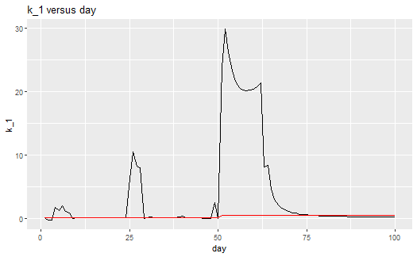

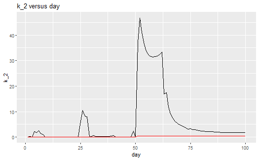

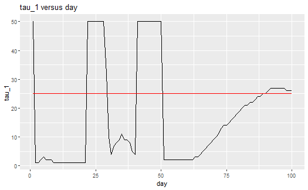

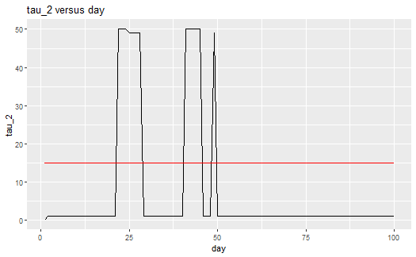

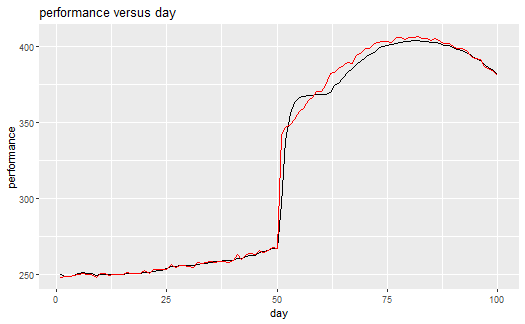

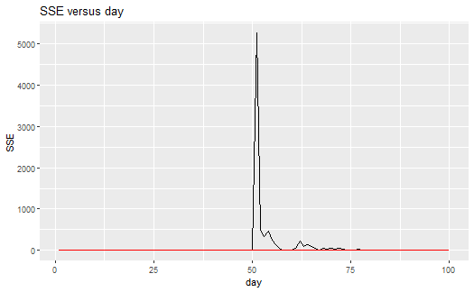

```r
params_list_traing = list(c(250,.1,.1,25,15), c(250,.5,.5,25,15)) # same as test 1
training_triang <- c(1:50, 50:1)
change_date_triang <- 50

test_triang = list(
  params_list_traing,
  training_triang,
  change_date_triang
)
(plots_triang <- prediction_with_alpha(test_triang,
                                       alpha = .9,
                                       noise = TRUE,
                                       sd=1))
```

```r
(plots_triang <- prediction_with_alpha(test_triang,
                                       alpha = .9,
                                       noise = TRUE,
                                       sd=.01))
```

[output not shown]

```r
(plots_triang <- prediction_with_alpha(test_triang,
                                       alpha = .9,
                                       noise = TRUE,
                                       sd=.0001))
```

[output not shown]